# Eploratory Visualization of Ford Go-Bike Dataset

## Univariate Exploration

- Distribution of the Ride period (in minutes)

```python
# FInding the binsize to be used in the histogram plot
data['ride_period_min'].describe()
```

```
count    174952.000000
mean         11.733379
std          27.370082
min           1.016667
25%           5.383333
50%           8.500000
75%          13.150000
max        1409.133333
Name: ride_period_min, dtype: float64
```

```python
# histogram plot of duration_min to understand the distribution of the values
def trip_duration_min():
    #define a function to plot duration_min on a histogram to understand the distribution
    bin_size = 5
    bins = np.arange(0, data['ride_period_min'].max()+bin_size, bin_size)

    plt.figure(figsize=[9, 5])
    plt.hist(data = data, x = 'ride_period_min', bins = bins)
    plt.title('Histogram Plot of Trip Duration')
    plt.xlabel('Ride Period(min)')
    plt.ylabel('No. of Trips')
    plt.axis([-10, 200, 0, 80000])
```

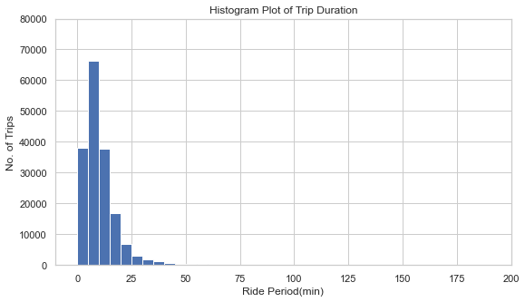

```python
# call the plot function
trip_duration_min()
```

> There is a very long tail in the distribution of Ride Period data. We will have to try same data with the violin plot.

```python
# violin plot
def violinplot_ride_period_min():
    #create a function to plot duration on a violin plot
    sns.violinplot(data = data, x = 'ride_period_min');
```

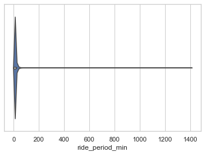

```python
#call the violinplot function
violinplot_ride_period_min()
```

> There is equally a long tail here runnning to over 1400 in Ride duration, for this reason we will have to apply the log scale.

```python
def log_hist():
    # define a function to plot a log scale for our visualization
    bin_size_log = 0.025
    bins = 10 ** np.arange(0, np.log10(data['ride_period_min'].max())+bin_size_log, bin_size_log)

    plt.figure(figsize=[10, 5]);
    plt.hist(data = data, x = 'ride_period_min', bins = bins);
    plt.xscale('log');
    plt.xticks([1, 2, 5, 10, 20, 50, 100, 200, 500, 1000, 2000], [1, 2, 5, 10, 20, 50, 100, 200, 500, 1000, 2000]);
    plt.xlabel('Ride Period(min)');
    plt.ylabel('No. of Trips');
```

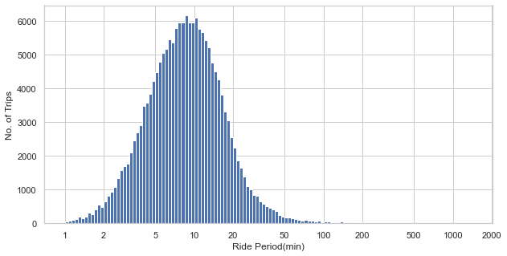

```python
log_hist()
```

> Now we have a normal distribution but with the outliers very visible. So, I will have to investigate and cut them

```python
# Let's investigate duration_min above 100 minutes
mins100 = data[data['ride_period_min']> 100] # ride periods greater than 100 minutes
mins100['ride_period_min'].describe()
```

```
count     703.000000
mean      301.537174
std       290.643431
min       100.216667
25%       122.100000
50%       168.400000
75%       331.091667
max      1409.133333
Name: ride_period_min, dtype: float64
```

> Over 700 trips out of 174952 fall between 100 and 1409 minutes. Let's investigate further and see what we can get.

```python
# Let's investigate duration_min 120 minutes and above
mins120 = data[data['ride_period_min'] >= 120]  # ride periods greater than 100 minutes
mins120['ride_period_min'].describe()
```

```
count     538.000000
mean      360.694641
std       309.001370
min       120.016667
25%       148.320833
50%       218.733333
75%       436.104167
max      1409.133333
Name: ride_period_min, dtype: float64
```

- 538 trips fall between 120 and 1409 minutes. These trips will be dropped so we can have a cleaner and less outliers.

```python
# Now we trim and view the new dataframe comprised of 120 minutes or less
data = data[data['ride_period_min'] <= 120]
data.info()
```

```
<class 'pandas.core.frame.DataFrame'>
Int64Index: 174414 entries, 4 to 183411
Data columns (total 20 columns):
 #   Column                   Non-Null Count   Dtype
---  ------                   --------------   -----
 0   start_time               174414 non-null  datetime64[ns]
 1   end_time                 174414 non-null  datetime64[ns]
 2   start_station_id         174414 non-null  object
 3   start_station_name       174414 non-null  object
 4   start_station_latitude   174414 non-null  float64
 5   start_station_longitude  174414 non-null  float64
 6   end_station_id           174414 non-null  object
 7   end_station_name         174414 non-null  object
 8   end_station_latitude     174414 non-null  float64
 9   end_station_longitude    174414 non-null  float64
 10  bike_id                  174414 non-null  object
 11  user_type                174414 non-null  category
 12  member_birth_year        174414 non-null  int32
 13  member_gender            174414 non-null  object
 14  bike_share_for_all_trip  174414 non-null  bool
 15  month                    174414 non-null  object
 16  day                      174414 non-null  category
 17  ride_period_min          174414 non-null  float64
 18  start_hour               174414 non-null  int64
 19  age                      174414 non-null  int32
dtypes: bool(1), category(2), datetime64[ns](2), float64(5), int32(2), int64(1), object(7)
memory usage: 23.1+ MB
```

- With this, we have 174414 observations.

```python
# new dataframe description
data['ride_period_min'].describe()
```

```
count    174414.000000
mean         10.656968
std           8.981459
min           1.016667
25%           5.366667
50%           8.483333
75%          13.083333
max         119.566667
Name: ride_period_min, dtype: float64
```

```python
# plotting the new data
def trimmed_histplot():
    #function to plot a histogram on the trimmed duration
    bin_size_log = 0.02
    bins = 10 ** np.arange(0, np.log10(data['ride_period_min'].max()) + bin_size_log, bin_size_log)

    plt.figure(figsize=[9, 5]);
    plt.hist(data = data, x = 'ride_period_min', bins = bins);
    plt.xscale('log');
    plt.xticks([1, 2, 5, 10, 20, 50, 100, 200, 500, 1000, 2000], [1, 2, 5, 10, 20, 50, 100, 200, 500, 1000, 2000]);
    plt.title('Histogram Plot of Trip Duration (Minutes)')
    plt.xlabel('Ride Period.')
    plt.ylabel('No. of Rides')
    plt.show()
```

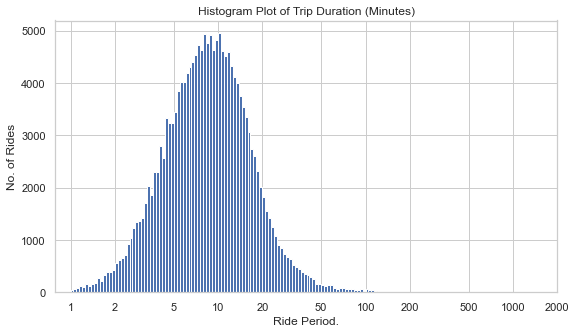

```python
trimmed_histplot()
```

> Normal Distribution achieved

### What is the Distribution of the Start hour?

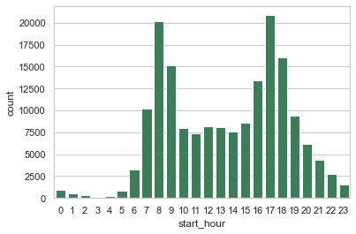

```python
color = 'seagreen'
sns.countplot(data = data , x = 'start_hour', color = color);
```

```python
plot_order = data['start_hour'].value_counts().index
```

```python
# We can see the order here
def start_time_plot():
    #define a function to plot starttime data
    sns.countplot(data = data , x = 'start_hour', color = color, order = plot_order);
    plt.title('Distribution of Rides across hours of the day')
    plt.xlabel('Start Hour of Rides')
    plt.ylabel('No. of Rides')
    plt.show()
```

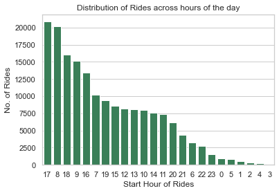

```python
start_time_plot()
```

- 17:00 and 8:00 are the hours of the day with the most rides.
- Very few rides occcured during the hours of 1:00, 2:00, 3:00 and 4:00

### What day of the week did the most rides take place?

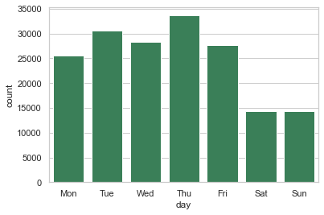

```python
sns.countplot(data = data, x = 'day', color = color);
```

```python
#create a plot for counts of start_time_dayofweek
def Ride_counts_Per_Weekday():
    #define a function to plot counts of dayofweek
    ax = plt.subplots(figsize=(10, 5))
    sns.countplot(y = 'day', data = data, color = 'c')
    plt.title('Rides across days of the Week', fontweight = 'bold', fontsize = 13)
    plt.xlabel('No. of Rides')
    plt.ylabel('Day of the Week')
```

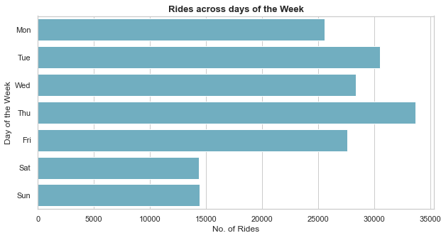

```python
#Call Counts_of_start_time_dayofweek
Ride_counts_Per_Weekday()
```

- The most rides took place on Thurdays followed by Tuesdays
- Week days seem to have more rides than weekends. Thursdays and Tuesdays have the most rides while Sundays and Saturdays have the least rides.

### Moving Forward, we will be looking at the riders more. We will look at their:

- Gender
- Age
- Type of Rider

## What Age groups of users are most active users of the Bikes?

```python
#Lets get a description of their ages
data['age'].describe()
```

```
count    174414.000000
mean         34.194268
std          10.119777
min          18.000000
25%          27.000000
50%          32.000000
75%          39.000000
max         141.000000
Name: age, dtype: float64
```

```python
# counts of gender category
data['age'].value_counts()
```

```
31     10190
26      9312
30      8901
29      8613
28      8462
       ...
91         1
141        1
89         1
109        1
92         1
Name: age, Length: 75, dtype: int64
```

> The age 141 is definitely an outlier since it is unsual. Let us confirm this with a boxplot

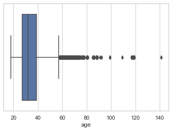

```python
sns.boxplot(data = data, x = 'age');
```

> The boxplot confirms my assumption and it counts 60 and above to be outliers. Before we proceed with this information, we need to know how many riders will be affected when we cut off the outliers from 60.

```python
#
testdata = data[data['age'] >= 60]
testdata['age'].describe()
```

```
count    4145.000000
mean       65.862485
std         9.034731
min        60.000000
25%        61.000000
50%        63.000000
75%        67.000000
max       141.000000
Name: age, dtype: float64
```

```python
test1data = data[data['age'] > 80]
test1data['age'].describe()
```

```
count    192.000000
mean      99.406250
std       15.261818
min       81.000000
25%       88.000000
50%       88.000000
75%      119.000000
max      141.000000
Name: age, dtype: float64
```

- Over 4000 of this data will be affected if i go by 60. In that case I will cut down froom 80 where I will only lose 192 data.

```python
#cut at age 80
data = data[data['age'] <= 80]
```

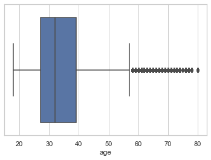

```python
#
sns.boxplot(data = data, x = 'age');
```

```python
data['age'].describe()
```

```
count    174222.000000
mean         34.122401
std           9.878039
min          18.000000
25%          27.000000
50%          32.000000
75%          39.000000
max          80.000000
Name: age, dtype: float64
```

```python
def plot_of_member_ages():
    #function to plot count of member ages
    bin_size = 2
    bins = np.arange(16, data['age'].max()+bin_size, bin_size)
    plt.hist(data = data, x = 'age', bins = bins, color = color);
    plt.title("Users' Age")
    plt.xlabel('Age')
    plt.ylabel('No. of Riders')
    plt.show()
```

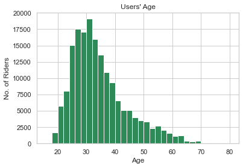

```python
#call plot_of_member_ages
plot_of_member_ages()
```

> Users of the Bike system are mostly between the ages of 25 and 40 years.

## Gender Distribution among users

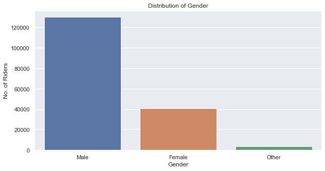

```python
# plotting genders
plt.figure(figsize=[10, 5])
sns.set_theme(style="darkgrid")
ax = sns.countplot(x="member_gender", data= data)
plt.title('Distribution of Gender')
plt.xlabel('Gender')
plt.ylabel('No. of Riders');
```

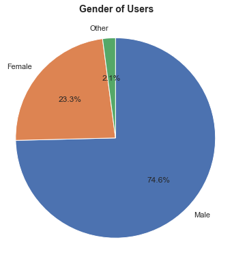

```python
# Plotting on the pie chart
gender_count = data['member_gender'].value_counts()

plt.figure(figsize =(10 ,6))
plt.pie(ordered_counts, labels = gender_count.index, startangle = 90, counterclock = False, autopct = '%1.1f%%');
plt.axis('square')
plt.title('Gender of Users', y=1.05, fontsize=14, fontweight = 'bold');
```

> Males make up over 70% of the gender users which is a tripple of the female gender.

## What are the different categories of users?

```python
#counts of each gender category
data['user_type'].value_counts()
```

```
Subscriber    157928
Customer       16294
Name: user_type, dtype: int64
```

```python
def plot_of_biker_types():
    #Create a function to plot the distribution of types of bikers
    sns.set_theme(style = "darkgrid")
    ax = sns.countplot(x = "user_type", data = data)
    plt.title('Distribution of Type of Bikers')
    plt.xlabel('Type of Users')
    plt.ylabel('No. of Riders');
```

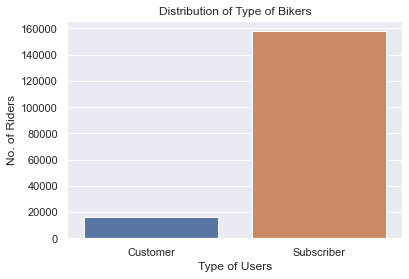

```python
plot_of_biker_types()
```

### Discuss the distribution(s) of your variable(s) of interest. Were there any unusual points? Did you need to perform any transformations?

- Variables of interest are Ride periods, member gender, user_type, duration_sec, start_time, and age.
- There were unusual points in the ride_periods_min(extracted from duration_sec), so, I converted the column values to logarithm scale and plotted them on a histogram.
- I also used member_gender and user_type were also used in my exploration.
- Age had outliers between 80 and above which were removed from the dataset. the most active age group is observed to be between 25 and 40 years

### Save cleaned Dataset for the presentation

> TIme to save the cleaned dataset so that there will be no need for cleaning again in the slides notebook will

```python
#save to csv
data.to_csv('cleaned_fordgobike_tripdata.csv', index=False)
```

# Bivariate Exploration

### Investigating the relationship between Member Age and Duration of Trips

```python
# CHecking the relationship between age of members and how much time their trips took
def ageVS_rideTime():
    # Define a function to plot duration and age
    plt.figure(figsize=[8,5])
    sns.scatterplot(data = data, x = 'age', y = 'ride_period_min', alpha = 0.25, marker = '.')
    plt.axis([10, 100, 1, 130])
    plt.title('Trip Duration and Age')
    plt.xlabel('Member Age')
    plt.ylabel('Ride Period (mins)')
    plt.show()
    print('The plot shows that riders between the ages of 20 and 40 years rode for longer time-upto 40 minutes while ages above 50 were only able to ride for shorter time. In essence, as the age of riders increased, the time spent riding reduced')
```

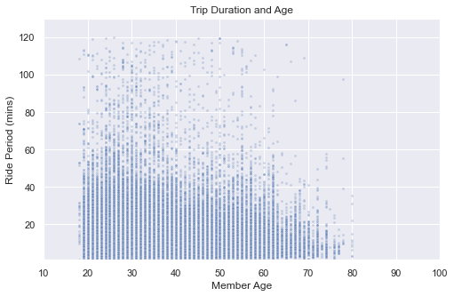

```
The plot shows that riders between the ages of 20 and 40 years rode for longer time-upto 40 minutes while ages above 50 were only able to ride for shorter time. In essence, as the age of riders increased, the time spent riding reduced
```

```python
#Call plot function
ageVS_rideTime()
```

- We may have to investigate this relationship further with a log tranformation of the trip duration data

```python
# Scatter plot of log transformed duration and member ages
def ageVSlogDuration():
    plt.figure(figsize=[20, 8])
    sns.scatterplot(data = data, x = 'age', y = 'ride_period_min', alpha = 0.5, s = 20, color = 'black')
    plt.title('Trip duration(log) and Member Age', fontsize = 14, fontweight = 'semibold')
    plt.xlabel('Member Ages');
    plt.yscale('log');
    plt.yticks([1, 2, 5, 10, 20, 50, 100], [1, 2, 5, 10, 20, 50, 100]);
    plt.ylabel('Ride period(mins.)');
```

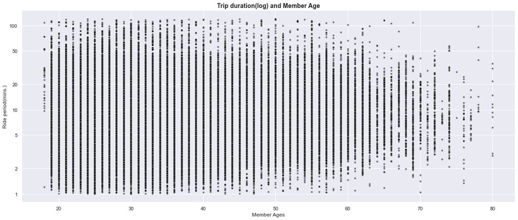

```python
#
ageVSlogDuration()
```

### Number of Trips by User Categories For Every Hour of the Day

```python
# Analysis of the number of trips taken by different user types across a hour of the day
def biker_h():
    g = sns.catplot(x = 'start_hour',
                col = 'user_type' ,
                kind = 'count', data = data, sharey = False, color = color)
    g.fig.subplots_adjust(top = 0.85)
    g.fig.suptitle('Number of Trips by User Categories For Every Hour of the Day', fontweight = 'bold');
```

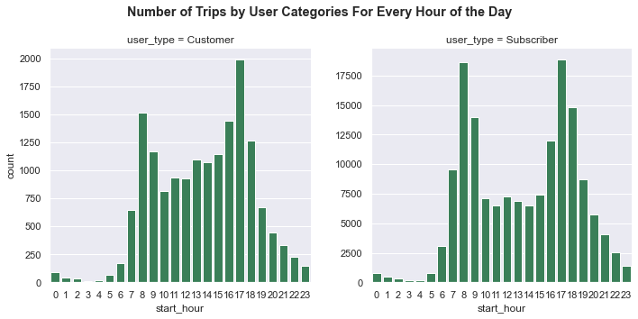

```python
biker_h()
```

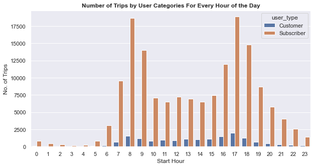

```python
plt.figure(figsize=[10,5])
sns.countplot(x = "start_hour", hue="user_type", data=data);
plt.title('Number of Trips by User Categories For Every Hour of the Day', fontsize = 12, fontweight = 'bold')
plt.xlabel('Start Hour');
plt.ylabel('No. of Trips');
```

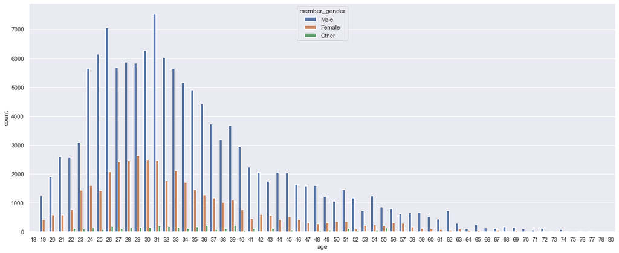

```python
sns.set(rc={'figure.figsize':(20, 8)})
ax = sns.countplot(x="age", hue="member_gender", data=data)
```

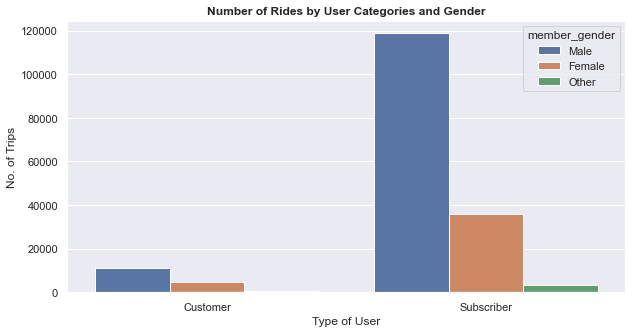

```python
plt.figure(figsize=[10,5])
ax = sns.countplot(x = 'user_type', hue = 'member_gender', data = data)
plt.title('Number of Rides by User Categories and Gender', fontsize = 12, fontweight = 'bold')
plt.xlabel('Type of User');
plt.ylabel('No. of Trips');
```

### Talk about some of the relationships you observed in this part of the investigation. How did the feature(s) of interest vary with other features in the dataset?

- Major part of my project centred on to duration of rides. I have also studied how the trip duration relates to member ages, trip start time(hour of the day), and user types.

### Did you observe any interesting relationships between the other features (not the main feature(s) of interest)?

- I looked into the relationship age had on users' ride_period_min, my investigation showed that riders who are between the ages of 20 and 40 rode for a longer time than those above 50.
- The result of the investigation was the same for the log-transformed ride_period_min column.
- My exploration of the number of rides each category of user took per every start hour showed that: a. Subscribers took the highest number of rides, b. Subscribers and customers started most trips during 8:00 hours and 17:00 hours, c. The least number of rides started at 3:00 and 4:00 hours.
- On gender and user type, male subscribers took the most rides in all. Male customers took more rides than female customers, but female subscribers took more rides than male customers.

# Multivariate Exploration

### Average trip duration per user type according to day of the week

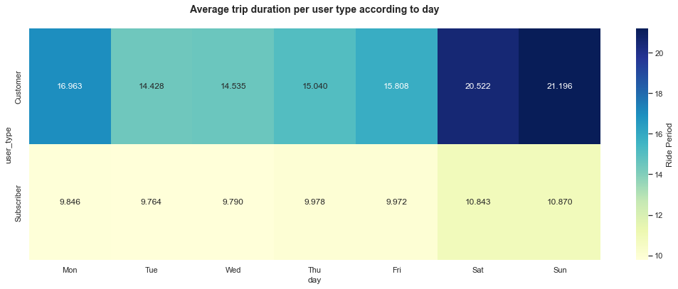

```python
plt.figure (figsize=(18, 6))
gmeans = data.groupby(['day', 'user_type']).mean()['ride_period_min']
gmeans = gmeans.reset_index(name = 'ride_period_min(avg)')
gmeans = gmeans.pivot(index = 'user_type', columns = 'day',
                            values = 'ride_period_min(avg)')
plt.title('Average trip duration per user type according to day', y=1.05, fontsize=14, fontweight='semibold')
sns.heatmap(gmeans, annot = True, fmt = '.3f',
           cbar_kws = {'label' : 'Ride Period'}, cmap = 'YlGnBu');
```

> The highest duration of trips (minutes) for both customers and subscribers is during weekends (Saturday and Sundays)

### Relationship among categories of user type, trip duration and member age

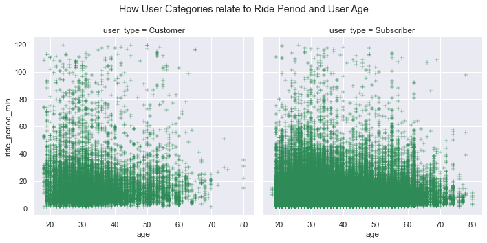

```python
bplot = sns.relplot(data = data, x = 'age', y = 'ride_period_min', col='user_type',
                    kind='scatter', marker = '+', color = color, alpha = 1);

bplot.fig.subplots_adjust(top = 0.85) # adjust the Figure in bplot
bplot.fig.suptitle('How User Categories relate to Ride Period and User Age');
```

### Talk about some of the relationships you observed in this part of the investigation. Were there features that strengthened each other in terms of looking at your feature(s) of interest?

# Resources

- https://pandas.pydata.org/pandas-docs/stable/reference/api/pandas.Series.dt.strftime.html
- https://stackoverflow.com/questions/9847213/how-do-i-get-the-day-of-week-given-a-date
- https://www.geeksforgeeks.org/how-to-change-the-position-of-legend-using-plotly-python/
- https://seaborn.pydata.org/generated/seaborn.boxplot.html
- https://seaborn.pydata.org/tutorial/categorical.html
- https://seaborn.pydata.org/generated/seaborn.scatterplot.html
- https://seaborn.pydata.org/tutorial/axis_grids.html
- https://stackoverflow.com/questions/31632637/label-axes-on-seaborn-barplot